# Assignment-4

```
                                                                         Partner Name:Anurag Tanaji Hambir

                                                                            Partner userid:ahambir@iu.edu

                           "All the work herein is solely mine"
```

# Problem 1: Algorithm Design 1

Suppose you are given two sequences D 1 and D 2 of n elements, possibly containing duplicates,on which a total order relation is defined. Describe an efficient algorithm for determining if D1 and D2 contain the same set of elements. What is the running time of this method?

## Solution

### Case1:

**If there are only unique elements in both the sequences:** We can hash both the sequences and this happens in linear time O(n).

- First iterate through the sequence D1 and store it as a key in hashtable.
- Similarly iterate through the sequence D2 and store it as a key in hashtable.
- Check for every element in D2, if there is a entry in D1 hashtable.If any element does not find the entry D1 hashtable then teh sequences are not equal.

**Pseudocode:**

```
checkEqualSequenceHash(D1, D2)
 // initialise hashtables D1 and D2
    let D1= hashtable()
    let D2= hashtable()

    if D1.length != D2.length
        return "Not equal set of sequence"

    #assign default values as true
    for i= 0 to D1.length
        assign D1[i] to true
    for i= 0 to D2.length
        assign D2[i] to true

    #check if all elements of D1 in D2
    for i = 0 to D1.length
        if D1[i] not in D2
            return "sequences are not same"

    #check if all elements of D2 in D1
    for i = 0 to D2.length
        if D2[i] not in D1
            return "sequences are not same"

    return "Sequences are same"
```

#### Runtime:

We can observe that every loop runs with a time complexity of O(n).

Since there are 4 for loops total runtime is 4*O(n)

> O(4n) is equal to O(n)

### Case2:

**If there are duplicate elements in the sequences:** We need to sort the sequences first and then check if there are equal. This runs in O(nlogn) time.

- Sort the sequences using mergesort, quicksort, heapsort (keeping in mind the constraints for these algorithms).
- After sorting compare the elements one by one if they are equal.

**Pseudocode:**

```
checkEqualSequencesSorting(D1,D2)
    //check if the two sequences are equal
    if D1.length!= D2.length
        return "Not equal sequences"

    //Sort D1 and D2
    //sort can be quciksort, mergesort etc
    D1 = sort(D1)

    D2 = sort(D2)

    //compare elements of D1 and D2
    while i= 0 to D1.length and j=0 to D2.length
        if D1[i] != D2[j]
            return "sequences are not equal"

    return "Sequences are equal"
```

#### Runtime:

The total runtime would be O(nlogn). We know that sorting algorithms have time compelxity of nlogn and the comparing operation will take O(n) time. So the total time taken will be O(nlogn + n) will be

> O(nlogn +n ) is equal to O(nlogn)

# Problem 2: Algorithm Design 2

Given an array D of n integers in the range [0, n<sup>2</sup> − 1], describe a simple method for sorting D in O(n) time.

## **Solution:**

We can sort using Radix Sort because the runtime of Quicksort, mergesort, heapsort are O(nlogn). If we consider counting sort it runs in O(n<sup>2</sup>) for the given given range 0 to n<sup>2</sup> − 1.

Given n d-digit numbers in which each digit can take on up to k possible values, Radix Sort correctly sorts these numbers in Θ(d(n + k)) time if the stable sort it uses takes Θ(n + k) time.

### Algorithm of Radix Sort:

```
RADIX_SORT(A,d)
    for i = 1 -> d
        use a stable sort to sort the array A on digit i
        *We will use count sort since it is a stable sort*
```

### Complete Algorithm:

```
COUNTING_SORT(D,B,k)
    INPUT: List of unsorted elements D,
           B is output array defined to store output list,
           k is max element in D
    OUTPUT:List of sorted elements in B
    /* len(D) = len(B), max(D) = k*/.
    Create a new array C[0..K]
    input_length = len(D)
    for i = 0 → k do
    C[i] = 0
    end
    for j = 1 → input_length do
    C[D[j]] = C[D[j]] + 1
    end
    for i = 1 → k do
    C[i] = C[i] + C[i − 1]
    end
    for j = input_length downto 1 do
    B[C[D[j]]] = D[j]
    C[D[j]] = C[D[j]] − 1
    end
```

```
RADIX_SORT(A,d)
    B= Array of length of A
    for i = 1 -> d
        COUNTING_SORT(A,B,k)
```

> *Radix Sort takes O(d*(n+b)) time where b is the base for representing numbers and d is the number of digits in the input number.Since n<sup>2</sup>-1 is the maximum possible value, the value of d would be O(log<sub>b</sub>(n)). So overall time complexity is O((n+b)*O(log<sub>b</sub>(n)). So if we take the base as n then the value of O(log<sub>b</sub>(n)) becomes O(1) and overall time complexity becomes O(n)*

# Problem 3: Algorithm Design 3

Given a sequence D of n elements, on which a total order relation is defined, describe an efficient method for determining whether there are two equal elements in D. What is the running time of your method?

### Solution:

The approach to design this algorithm is:

- Check if the list is empty or conatins only 1 element.
- Sort the sequence D using any of the sorting algorithms.
- Compare element with its consecutive element to check for equal elements.

#### **Pseudocode:**

```
TwoEqualElements(D)
    n=D.length
    //if only one elements exists in sequence
    if n <= 1
        print ("No Equal elemnts found")
    //Sort the sequence D
    sort D

    for i = 0 to n
        //check if two consecutive elements are equal
        if D[i] == D[i+1]
            return "Equal elements found"

    return "no equal elements in the list"
```

### Runtime:

The algorithm mainly has two major operations which take high growth of order. The remaining operations run in constant time O(1).

- The sorting function takes O(n) or O(nlogn) when counting sort, mergesort, quicksort, heapsort etc are used.
- The comparing operating takes O(n) if there are no equal elements found in the sequence.

So the total runtime would be O(nlogn+n)

> O(nlogn+n) is equal to O(nlogn) - if the sort function used is O(nlogn).

# Problem 4: Merge-sort

Implement a bottom-up merge-sort for a collection of items by placing each item in its own queue, and then repeatedly merging pairs of queues until all items are sorted within a single queue.

```python
from collections import deque
import random
import time
import matplotlib.pyplot as plt

##Define merge method, I took the same merge method from the Top-Down algo example provided.
def merge(left_list, right_list):
    low = high = 0
    aux_list = []
    while low < len(left_list) and high < len(right_list):
        if left_list[low] < right_list[high]:
            aux_list.append(left_list[low])
            low += 1
        else:
            aux_list.append(right_list[high])
            high += 1

    # append what is remained in either of the lists
    aux_list.extend(left_list[low:])
    aux_list.extend(right_list[high:])
#     print(aux_list)
    return aux_list

def mergesort(ListA):
    ##First, break list into a list of lists e.g [[1],[4], ...]

    ##Second, store lists in queue.
    queue = deque()
    for i in ListA:
        queue.append([i])

    ##Merge Sort Bottom-up method starts here.
    while(len(queue) > 1):
    #Pop left and right lists from queue
        left_list = queue.popleft()
        right_list = queue.popleft()
    #Merge lists until there is one list left in the queue
        queue.append(merge(left_list,right_list))

    #Pop last remaining sorted list
    sorted_list = queue.pop()
    for i in range(len(ListA)):
        ListA[i]= sorted_list[i]
```

```python
#Unordered list with unique values
ListS=[1,2,9,3,7,17,74,19,999]
mergesort(ListS)
print(ListS)

#Sorted list with unique values
A=[1,2,3,4,5]
mergesort(A)
print(A)

#sorted list in descending order
B=[5,4,3,2,1]
mergesort(B)
print(B)

#duplicate list element
C=[5,5,5,5,5]
mergesort(C)
print(C)
```

```
[1, 2, 3, 7, 9, 17, 19, 74, 999]
[1, 2, 3, 4, 5]
[1, 2, 3, 4, 5]
[5, 5, 5, 5, 5]
```

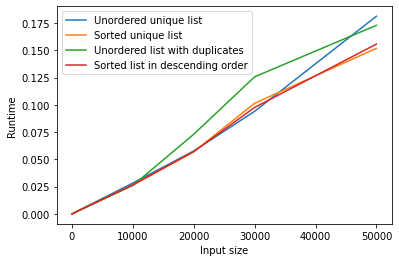

```python
### For Comparing Time complexity for different input sizes
# n=[i for i in range(1,100,10)]
n=[10, 100,1000, 10000, 20000, 30000,50000]
final_time1=[]
final_time2=[]
final_time3=[]
final_time4=[]
for i in n:
#     S = [rn.randint(1,100) for _ in range(i)]
    S = list(random.sample(range(0,i),i))
    #to create a sample sorted array for input to test
    S1 = S.copy()
    sorted(S1)
    S2 = [random.choice(range(i//2)) for j in range(i)]
    S3=S.copy()
    sorted(S3,reverse=True)
    start1 = time.perf_counter()
    mergesort(S)
    final_time1.append(time.perf_counter()-start1)
    start2 = time.perf_counter()
    mergesort(S1)
    final_time2.append(time.perf_counter()-start2)
    start3 = time.perf_counter()
    mergesort(S2)
    final_time3.append(time.perf_counter()-start3)
    start4 = time.perf_counter()
    mergesort(S3)
    final_time4.append(time.perf_counter()-start4)
# print(final_time4)
plt.xlabel("Input size")
plt.ylabel("Runtime")
plt.plot(n,final_time1, label = "Unordered unique list")
plt.plot(n,final_time2, label = "Sorted unique list")
plt.plot(n,final_time3, label = "Unordered list with duplicates")
plt.plot(n,final_time4, label = "Sorted list in descending order")
plt.legend()
```

### Output:

Given an unsorted queue it gives a sorted queue. Example:

```
ListS=[1,2,9,3,7,17,74,9]
mergesort(ListS)
print(ListS)
```

> **Output:** [1, 2, 3, 7, 9, 9, 17, 74]

### Implementation:

In the above program we have written 2 functions

### Runtime

Mergesort runs with time complexity of O(nlogn).Merge() function runs in linear time and mergesort function runs in O(logn). Therefor total runtime is O(nlogn).

### Graph Analysis:

The graph is plotted to analysis behaviour of merge sort algorithm for different sizes and variety of input.We have considered:

- Unordered unique list
- Sorted unique list
- Unordered list with duplicates
- Sorted list in descending order

We can observe that all the variety of input runs with the same runtime complexity for different input sizes.The growth is similar to O(nlogn).

# Problem-5 : Heap Sort

Implement the heap-sort algorithm given in algorithm 1. The max_heapify and build_max_heap procedures are described in algorithm 2 and algorithm 3, respectively.

```python
import matplotlib.pyplot as plt
import random as rn
import time


# initialise parent node
def parent(i):
    return i // 2

#Initialise left child
# Since using 0 based index returns 2(i+1)-1
def left_child(i):
    return (2 * (i + 1)) - 1

#Initialise right child
# Since using 0 based index returns2(i+1)
def right_child(i):
    return 2 * (i + 1)

#Heapify the list input at index i and given heapsize
def max_heapify(ListA, i, heap_size):
    left = left_child(i)
    right = right_child(i)
    if left <= heap_size and ListA[left] > ListA[i]:
        largest = left
    else:
        largest = i
    if right <= heap_size and ListA[right] > ListA[largest]:
        largest = right
    if largest != i:
        # print("before swap : ", ListA)
        ListA[i], ListA[largest] = ListA[largest], ListA[i]
        # print("swap happened? : ", ListA)
        max_heapify(ListA, largest, heap_size)

#build max heap
def build_max_heap(ListA):
    A_heapsize = len(ListA) - 1
    for i in range(A_heapsize // 2, -1, -1):
        max_heapify(ListA, i, A_heapsize)

#call heapsort by combining above methods
def heapsort(ListA):
    build_max_heap(ListA)
    # print("after building max heap: ", ListA)
    n = len(ListA) - 1
    for i in range(len(ListA) - 1, 0, -1):
        ListA[0], ListA[i] = ListA[i], ListA[0]
        n = n - 1
        max_heapify(ListA, 0, n)
    return ListA
```

```python
#call heap sort

#Unordered list with unique values
ListS=[1,2,9,3,7,17,74,19,999]
heapsort(ListS)
print(ListS)

#Sorted list with unique values
A=[1,2,3,4,5]
heapsort(A)
print(A)

#sorted list in descending order
B=[5,4,3,2,1]
heapsort(B)
print(B)

#duplicate list element
C=[5,5,5,5,5]
heapsort(C)
print(C)
```

```
[1, 2, 3, 7, 9, 17, 19, 74, 999]
[1, 2, 3, 4, 5]
[1, 2, 3, 4, 5]
[5, 5, 5, 5, 5]
```

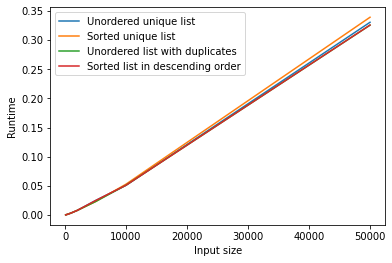

```python
# n=[i for i in range(1,100,)]
n=[100,150,300,500,600,900,1000, 2000, 5000, 10000,50000]
final_time1=[]
final_time2=[]
final_time3=[]
final_time4=[]
for i in n:
#     S = [rn.randint(1,100) for _ in range(i)]
    S = list(random.sample(range(0,i),i))
    #to create a sample sorted array for input to test
    S1 = S.copy()
    sorted(S1)
    S2 = [random.choice(range(i//2)) for j in range(i)]
    S3=S.copy()
    sorted(S3,reverse=True)
    start1 = time.perf_counter()
    heapsort(S)
    final_time1.append(time.perf_counter()-start1)
    start2 = time.perf_counter()
    heapsort(S1)
    final_time2.append(time.perf_counter()-start2)
    start3 = time.perf_counter()
    heapsort(S2)
    final_time3.append(time.perf_counter()-start3)
    start4 = time.perf_counter()
    heapsort(S3)
    final_time4.append(time.perf_counter()-start4)
# print(final_time4)
plt.xlabel("Input size")
plt.ylabel("Runtime")
plt.plot(n,final_time1, label = "Unordered unique list")
plt.plot(n,final_time2, label = "Sorted unique list")
plt.plot(n,final_time3, label = "Unordered list with duplicates")
plt.plot(n,final_time4, label = "Sorted list in descending order")
plt.legend()
```

### Output:

**Input:** [2,11, -2, 7, 3, 6, 8, -10, 3, 11]

```
A = [2,11, -2, 7, 3, 6, 8, -10, 3, 11]
print("Sorted list using heapsort=",heapsort(A))
heapsort(A)
```

**Output:** Sorted list using heapsort= [-10, -2, 2, 3, 3, 6, 7, 8, 11, 11]

### Implementation:

Heap sort is a inplace algorithm which uses heap data structure.In this heapsort we use max heap to sort the elements. Heaps has nodes as Parent(i),Left_child(i),Right_child(i).Heapsort has two attributes:

- Length of input
- Heap size

**_max*heapify()*:** We use the max_heapify function which runs at node i to convert the node in correspondence to max heap. If the element at the node i is smaller than its children then we swap it with the higher value element with the parent.

**_Build_max*heap()*:** The input needs to be built into max heap datastructure initially.It runs for half of length because the remaining nodes will be leaf nodes.

*Heapsort()*: We need to first build max heap using *build-max-heap()* Then we iterate over the input and Remove the root node and exchange it with the last node element and call max_heapify again to contruct the max heap structure.

Note: The implementation is 0 index based.

### Runtime:

Heapsort runs with time complexity of O(nlogn).The _max*heapify()* runs with a time complexity of O(logn) and _build_max*heap()* runs with a complexity of O(n). The total run time is

> O(logn + n) is equal to O(nlogn)

### Graph Analysis:

The graph is plotted to analysis behaviour of heapsort algorithm for different sizes and variety of input.We have considered:

- Unordered unique list
- Sorted unique list
- Unordered list with duplicates
- Sorted list in descending order

We can observe that all the variety of input runs with the same runtime complexity for different input sizes.The growth is similar to O(nlogn).

# Problem 6: Counting Sort

Implement the counting-sort algorithm given in algorithm 4.

```python
def counting_sort(inputA, outputB, k):
    input_length = len(inputA)
    Freq_list = [0 for i in range(0, k+1)]
    #to get the frequency of numbers in inputA
    for j in range(0, input_length):
        Freq_list[inputA[j]] = Freq_list[inputA[j]] + 1
    # update the index positions storing the various elements in outputB
    for i in range(1, k+1):
        Freq_list[i] = Freq_list[i] + Freq_list[i-1]
    # to store the elemnts in sorted way in outputB
    for m in range(input_length-1, -1, -1):
        outputB[Freq_list[inputA[m]]-1] = inputA[m]
        Freq_list[inputA[m]] = Freq_list[inputA[m]] - 1
    return outputB
```

```python
#unordered list with unique values
ListA=[1, 2, 5, 4, 3]
ListB=[0 for i in range(len(ListA))]
k=max(ListA)
print(counting_sort(ListA,ListB,k))

#Sorted list with unique values
A=[1,2,3,4,5]
A1=[0 for i in range(len(A))]
k1=max(A)
print(counting_sort(A,A1,k1))


#sorted list in descending order
B=[5,4,3,2,1]
B1=[0 for i in range(len(B))]
k2=max(B)
print(counting_sort(B,B1,k2))

#duplicate list element
C=[5,5,5,5,5]
C1=[0 for i in range(len(C))]
k3=max(C)
print(counting_sort(C,C1,k3))
```

```
[1, 2, 3, 4, 5]
[1, 2, 3, 4, 5]
[1, 2, 3, 4, 5]
[5, 5, 5, 5, 5]
```

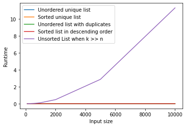

```python
def plot_grap_for_various_inputs():
        # n=[i for i in range(1,100,)]
    n=[100,150,300,500,600,900,1000, 2000, 5000, 10000]
    final_time1=[]
    final_time2=[]
    final_time3=[]
    final_time4=[]
    final_time5=[]
    for i in n:
    #     S = [rn.randint(1,100) for _ in range(i)]
        S = list(random.sample(range(0,i),i))
        #to create a sample sorted array for input to test
        S1 = S.copy()
        sorted(S1)
        S2 = [random.choice(range(i//2)) for j in range(i)]
        S3=S.copy()
        sorted(S3,reverse=True)
        S4 = S.copy()
        S4[0]=(i-1)*(i-1)

        ListB=[0 for i in range(len(S))]
        k1=max(S)
        start1 = time.perf_counter()
        counting_sort(S,ListB,k1)
        final_time1.append(time.perf_counter()-start1)

        ListB1=[0 for i in range(len(S1))]
        k2=max(S1)
        start2 = time.perf_counter()
        counting_sort(S1,ListB1,k2)
        final_time2.append(time.perf_counter()-start2)

        ListB2=[0 for i in range(len(S2))]
        k3=max(S2)
        start3 = time.perf_counter()
        counting_sort(S2,ListB2,k3)
        final_time3.append(time.perf_counter()-start3)

        ListB3=[0 for i in range(len(S3))]
        k4=max(S3)
        start4 = time.perf_counter()
        counting_sort(S3,ListB3,k4)
        final_time4.append(time.perf_counter()-start4)

        ListB4=[0 for i in range(len(S4))]
        k5=max(S4)
        start5 = time.perf_counter()
        counting_sort(S4,ListB4,k5)
        final_time5.append(time.perf_counter()-start5)
    plt.xlabel("Input size")
    plt.ylabel("Runtime")
    plt.plot(n,final_time1, label = "Unordered unique list")
    plt.plot(n,final_time2, label = "Sorted unique list")
    plt.plot(n,final_time3, label = "Unordered list with duplicates")
    plt.plot(n,final_time4, label = "Sorted list in descending order")
    plt.plot(n,final_time5, label = "Unsorted List when k >> n")
    plt.legend()

plot_grap_for_various_inputs()
```

### Output:

**Input:** [1, 2, 5, 4, 4, 3, 2]

```
ListA=[1, 2, 5, 4, 4, 3, 2]
ListB=[0 for i in range(len(ListA))]
k=max(ListA)
counting_sort(ListA,ListB,k)
```

**Output:** [1, 2, 2, 3, 4, 4, 5]

### Implementation:

Counting sort is a stable sorting algorithm which uses the technique of keeping count of elements repeated and calculating the index positions in the output array. Counting sort assumes that each of the n input elements is an integer 0 to k; for each k belongs to integer. Counting sort determines for each input element x the number of elements less than x.It uses this information to place element x directly into its position.

The _counting*sort()* takes input array, output array which has length of input array and max element in the input array as input. It gives a sorted array as output.It then initialises a Freq_list which stores the number of occurances of an element in the input list.We update the freq_lsit with the new indices for the elements in the ouput array.The length of freq_list is k. We traverse the elements from the end of input list and insert into the appropriate position in the output list.

### Runtime:

Counting sorts run with time complexity of O(n+k) assuming k is small. If k runs in O(n) then counting sort also runs in O(n).

### Graph Analysis:

The graph is plotted to analysis behaviour of counting sort algorithm for different sizes and variety of input.We have considered:

- Unordered unique list
- Sorted unique list
- Unordered list with duplicates
- Sorted list in descending order

# Problem 7:

Implement the bucket sort algorithm given in algorithm 5.

```python
import math

def Bucket_sort(input_list):

    input_length = len(input_list)

    #Create a list of buckets
    B = []
    for i in range(len(input_list)):
        B.append([])

    #Store the elements in buckets
    for i in range(0,len(input_list)):
        B[int(input_length*input_list[i])].append(input_list[i])

    #Insertion sort function to sort each bucket
    def insertion_sort(A):
        for i in range(0,len(A)):
            j = i - 1
            temp = A[i]
            while j >= 0 and temp < A[j]:
                A[j+1] = A[j]
                j -= 1
            A[j+1] = temp
        return A

    #Sort each list and append the lists
    sorted_list = []
    for i in range(len(input_list)):
        sorted_list = sorted_list + insertion_sort(B[i])
    return sorted_list
```

```python
#unique and uniformly distributed
S = [0.18,0.12,0.20,0.1,0.8,0.25,0.16]
print(Bucket_sort(S))

#duplicate elements
S1=[0.1,0.1,0.1,0.1,0.1]
print(Bucket_sort(S1))

#Sorted and Descending order
S2=[0.5,0.4,0.3,0.2,0.1]
print(Bucket_sort(S2))
```

```
[0.1, 0.12, 0.16, 0.18, 0.2, 0.25, 0.8]
[0.1, 0.1, 0.1, 0.1, 0.1]
[0.1, 0.2, 0.3, 0.4, 0.5]
```

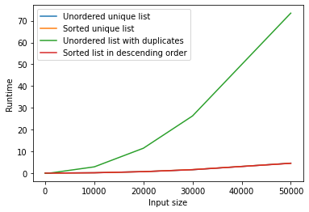

```python
def plot_grap_for_various_inputs():
        # n=[i for i in range(1,100,)]
    n=[10, 100, 1000, 10000, 20000, 30000, 50000]
#     n=[10, 100, 1000, 10000]
    final_time1=[]
    final_time2=[]
    final_time3=[]
    final_time4=[]
    for i in n:
    #     S = [rn.randint(1,100) for _ in range(i)]
        S = list(random.sample(range(0,i),i))
        for j in range(len(S)):
            S[j]=S[j]/i
        #to create a sample sorted array for input to test
        S1 = S.copy()
        sorted(S1)

        S2 = [random.choice(range(i//2)) for j in range(i)]
        for j in range(len(S2)):
            S2[j]=S[j]/i

        S3=S.copy()
        sorted(S3,reverse=True)

        start1 = time.perf_counter()
        Bucket_sort(S)
        final_time1.append(time.perf_counter()-start1)

        start2 = time.perf_counter()
        Bucket_sort(S1)
        final_time2.append(time.perf_counter()-start2)

        start3 = time.perf_counter()
        Bucket_sort(S2)
        final_time3.append(time.perf_counter()-start3)

        start4 = time.perf_counter()
        Bucket_sort(S3)
        final_time4.append(time.perf_counter()-start4)
    plt.xlabel("Input size")
    plt.ylabel("Runtime")
    plt.plot(n,final_time1, label = "Unordered unique list")
    plt.plot(n,final_time2, label = "Sorted unique list")
    plt.plot(n,final_time3, label = "Unordered list with duplicates")
    plt.plot(n,final_time4, label = "Sorted list in descending order")
    plt.legend()

plot_grap_for_various_inputs()
```

### Output:

**Input:** [0.18,0.12,0.20,0.1,0.8,0.25,0.16]

```
S = [0.18,0.12,0.20,0.1,0.8,0.25,0.16]
print(Bucket_sort(S))
```

**Output:** [0.1, 0.12, 0.16, 0.18, 0.2, 0.25, 0.8]

### Implementation:

Bucket sort works on the assumption that the input drawn is from the uniform distribution that is the input is generated by a random process that that distributes elements uniformly and independantly over a interval [0,1).

The bucket sort algorithm divides the interval [0,1) into n equal sized buckets. Since the input data is uniformly distributed a single bucket wont have many numbers.After putting into buckets we sort the elements in each bucket usng insertion sort algorithm.Then we concatenate the data from various buckets sequentially which gives us a sorted output list.

### Runtime:

The average case runtime of Bucket sort is O(n).Worst case of bucket sort can be O(n<sup>2</sup>) if all the keys fall in the same bucket and happen to be in reverse order. If the data is not unifromly distributed then the growth of fucntion follows the runtime of Insertion sort.

### Graph analysis:

The graph is plotted to analysis behaviour of bucket sort algorithm for different sizes and variety of input.We have considered:

- Unordered unique list
- Sorted unique list
- Unordered list with duplicates
- Sorted list in descending order